# Using infer

# Confidence intervals One numerical (one mean)

Finding the observed statistic, Alternatively, using the observe() wrapper to calculate the observed statistic,

```r
x_bar <- gss |>
  specify(response = hours) |>
  calculate(stat = "mean")
x_bar <- gss |>
  observe(response = hours, stat = "mean")
```

Then, generating a bootstrap distribution,

```r
boot_dist <- gss |>
   specify(response = hours) |>
   generate(reps = 1000, type = "bootstrap") |>
   calculate(stat = "mean")
```

Use the bootstrap distribution to find a confidence interval,

```r
percentile_ci <- get_ci(boot_dist)
```

Visualizing the observed statistic alongside the distribution,

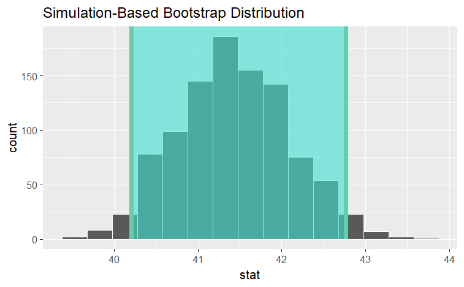

```r
visualize(boot_dist) +
  shade_confidence_interval(endpoints = percentile_ci)
```

Alternatively, use the bootstrap distribution to find a confidence interval using the standard error,

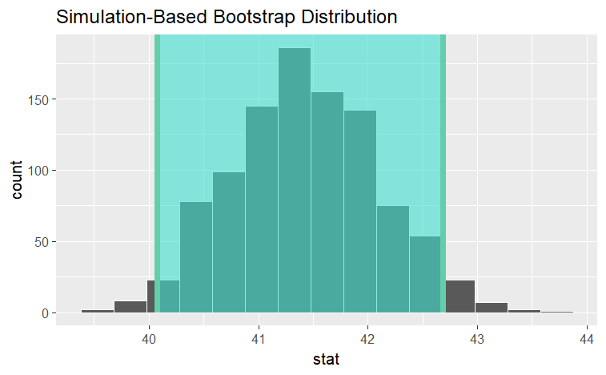

```r
standard_error_ci <- get_ci(boot_dist, type = "se", point_estimate = x_bar)
visualize(boot_dist) +
  shade_confidence_interval(endpoints = standard_error_ci)
```

Instead of a simulation-based bootstrap distribution, we can also define a theory-based sampling distribution, Visualization and calculation of confidence intervals interfaces in the same way as with the simulation-based distribution,

```r
sampling_dist <- gss |>
   specify(response = hours) |>
   assume(distribution = "t")
theor_ci <- get_ci(sampling_dist, point_estimate = x_bar)
theor_ci
```

| lower_ci | upper_ci |
| --- | --- |
| 40.07984 | 42.68416 |

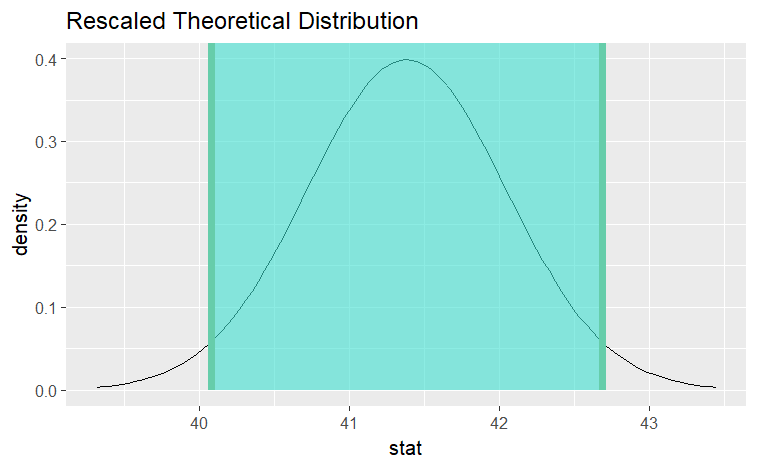

```r
visualize(sampling_dist) +
  shade_confidence_interval(endpoints = theor_ci)
```

Note that the t distribution is recentered and rescaled to lie on the scale of the observed data. `infer` does not support confidence intervals on means via the z distribution.

# One numerical (one mean - standardized)

- Finding the observed statistic,
- Alternatively, using the observe() wrapper to calculate the observed statistic,

```r
t_hat <- gss |>
  specify(response = hours) |>
  hypothesize(null = "point", mu = 40) |>
  calculate(stat = "t")
t_hat <- gss |>
  observe(response = hours,
          null = "point", mu = 40,
          stat = "t")
```

Then, generating the bootstrap distribution, Use the bootstrap distribution to find a confidence interval, Visualizing the observed statistic alongside the distribution,

```r
boot_dist <- gss |>
   specify(response = hours) |>
   # hypothesize(null="point", mu=40) %>%
   generate(reps = 1000, type = "bootstrap") |>
   calculate(stat = "t")

percentile_ci <- get_ci(boot_dist)
percentile_ci
```

| lower_ci | upper_ci |
| --- | --- |
| 58.31348 | 67.7446 |

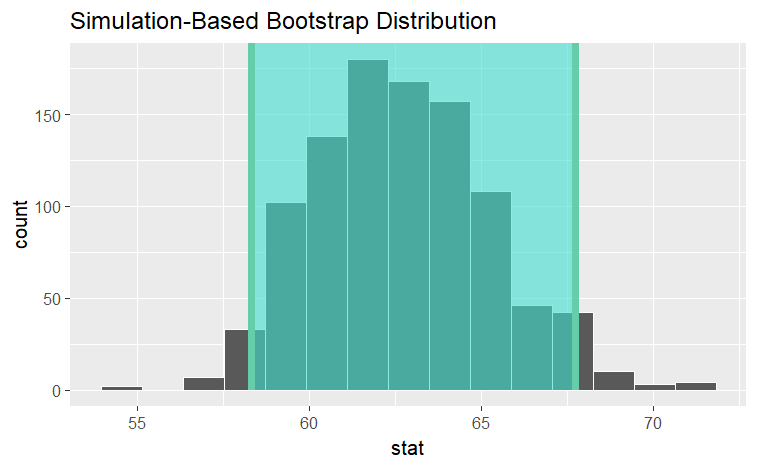

```r
visualize(boot_dist) +
  shade_confidence_interval(endpoints = percentile_ci)
```

# Wrong 1

Alternatively, use the bootstrap distribution to find a confidence interval using the standard error,

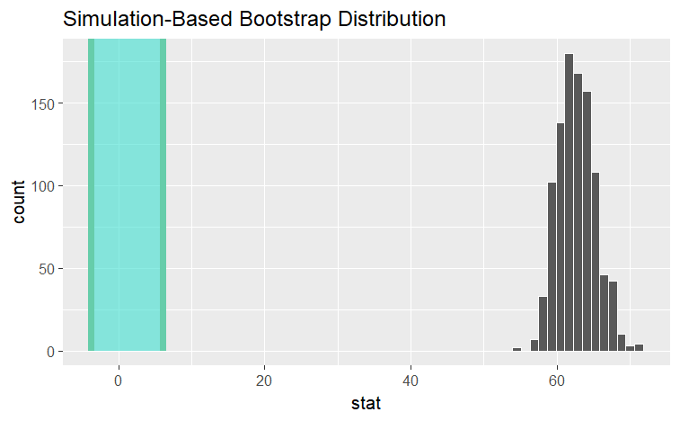

> type A string giving which method should be used for creating the confidence interval. The default is “percentile” with “se” corresponding to (multiplier * standard error) and “bias-corrected” for bias-corrected interval as other options.

> A null hypothesis is not required to compute a confidence interval. However, including hypothesize() in a pipeline leading to get_confidence_interval() will not break anything. This can be useful when computing a confidence interval using the same distribution used to compute a p-value.

Is this a bug in the `get_ci()` function with ‘type=“se”’

See the above subsection (one mean) for a theory-based approach. Note that infer does not support confidence intervals on means via the z distribution.

# One categorical (one proportion)

Finding the observed statistic, Alternatively, using the observe() wrapper to calculate the observed statistic,

```r
p_hat <- gss |>
   specify(response = sex, success = "female") |>
   calculate(stat = "prop")
p_hat <- gss |>
   observe(response = sex, success = "female", stat = "prop")
```

Then, generating a bootstrap distribution,

```r
boot_dist <- gss |>
 specify(response = sex, success = "female") |>
 generate(reps = 1000, type = "bootstrap") |>
 calculate(stat = "prop")
```

Use the bootstrap distribution to find a confidence interval,

```r
percentile_ci <- get_ci(boot_dist)
```

Visualizing the observed statistic alongside the distribution,

[figure not shown]

```r
visualize(boot_dist) +
  shade_confidence_interval(endpoints = percentile_ci)
```

Alternatively, use the bootstrap distribution to find a confidence interval using the standard error,

[figure not shown]

```r
standard_error_ci <- boot_dist |>
  get_ci(type = "se", point_estimate = p_hat)

visualize(boot_dist) +
  shade_confidence_interval(endpoints = standard_error_ci)
```

Instead of a simulation-based bootstrap distribution, we can also define a theory-based sampling distribution,

```r
sampling_dist <- gss |>
   specify(response = sex, success = "female") |>
   assume(distribution = "z")
```

Visualization and calculation of confidence intervals interfaces in the same way as with the simulation-based distribution,

```r
theor_ci <- get_ci(sampling_dist, point_estimate = p_hat)

theor_ci
```

| lower_ci | upper_ci |
| --- | --- |
| 0.4302332 | 0.5177668 |

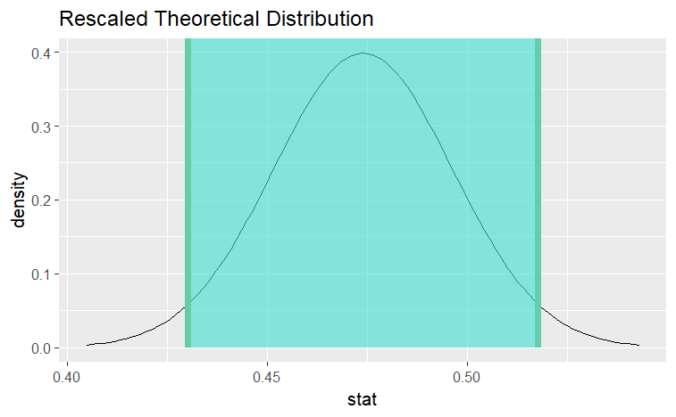

```r
visualize(sampling_dist) +
  shade_confidence_interval(endpoints = theor_ci)
```

Note that the z distribution is recentered and rescaled to lie on the scale of the observed data. `infer` does not support confidence intervals on means via the z distribution.

# One categorical variable (standardized proportion z)

See the above subsection (one proportion) for a theory-based approach.

#One numerical variable, one categorical (2 levels) (diff in means) Finding the observed statistic, Alternatively, using the observe() wrapper to calculate the observed statistic,

```r
d_hat <- gss |>
  specify(hours ~ college) |>
  calculate(stat = "diff in means", order = c("degree", "no degree"))
d_hat <- gss |>
  observe(hours ~ college,
          stat = "diff in means", order = c("degree", "no degree"))
```

Then, generating a bootstrap distribution,

```r
boot_dist <- gss |>
   specify(hours ~ college) |>
   generate(reps = 1000, type = "bootstrap") |>
   calculate(stat = "diff in means", order = c("degree", "no degree"))
```

Use the bootstrap distribution to find a confidence interval, Visualizing the observed statistic alongside the distribution,

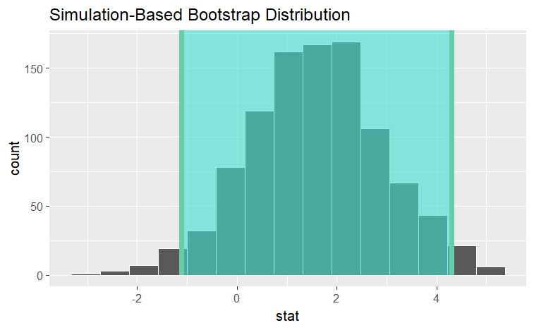

```r
percentile_ci <- get_ci(boot_dist)
visualize(boot_dist) +
  shade_confidence_interval(endpoints = percentile_ci)
```

Alternatively, use the bootstrap distribution to find a confidence interval using the standard error,

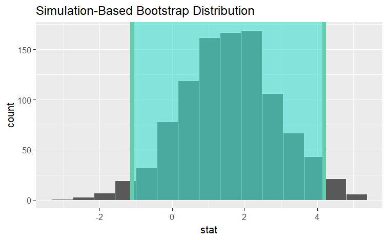

```r
standard_error_ci <- boot_dist |>
  get_ci(type = "se", point_estimate = d_hat)

visualize(boot_dist) +
  shade_confidence_interval(endpoints = standard_error_ci)
```

Instead of a simulation-based bootstrap distribution, we can also define a theory-based sampling distribution, Visualization and calculation of confidence intervals interfaces in the same way as with the simulation-based distribution,

```r
sampling_dist <- gss |>
   specify(hours ~ college) |>
   assume(distribution = "t")
theor_ci <- get_ci(sampling_dist, point_estimate = d_hat)

theor_ci
```

| lower_ci | upper_ci |
| --- | --- |
| -1.164381 | 4.241245 |

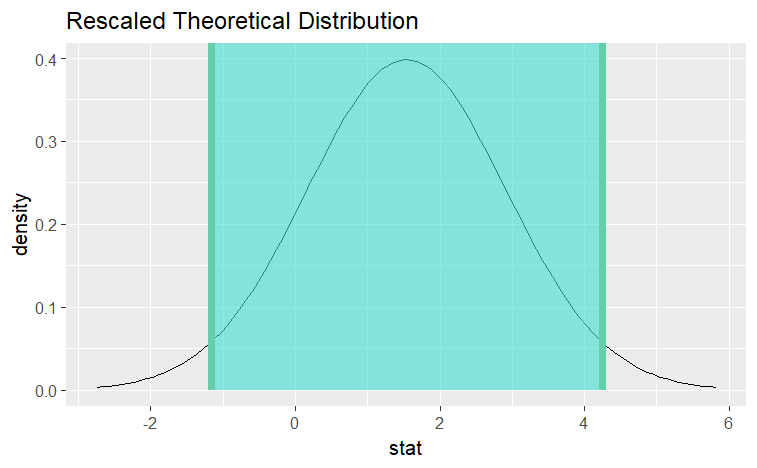

```r
visualize(sampling_dist) +
  shade_confidence_interval(endpoints = theor_ci)
```

Note that the t distribution is recentered and rescaled to lie on the scale of the observed data.

`infer` also provides functionality to calculate ratios of means. The workflow looks similar to that for `diff in means`.

Finding the observed statistic, Alternatively, using the observe() wrapper to calculate the observed statistic,

```r
d_hat <- gss |>
  specify(hours ~ college) |>
  calculate(stat = "ratio of means", order = c("degree", "no degree"))
d_hat <- gss |>
  observe(hours ~ college,
          stat = "ratio of means", order = c("degree", "no degree"))
```

Then, generating a bootstrap distribution,

```r
boot_dist <- gss |>
   specify(hours ~ college) |>
   generate(reps = 1000, type = "bootstrap") |>
   calculate(stat = "ratio of means", order = c("degree", "no degree"))
```

Use the bootstrap distribution to find a confidence interval, Visualizing the observed statistic alongside the distribution,

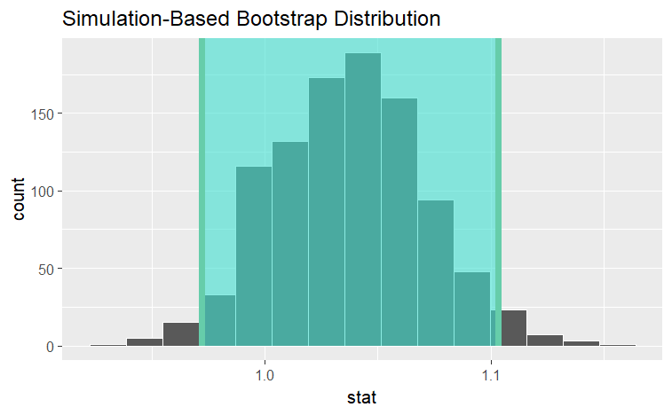

```r
percentile_ci <- get_ci(boot_dist)
visualize(boot_dist) +
  shade_confidence_interval(endpoints = percentile_ci)
```

Alternatively, use the bootstrap distribution to find a confidence interval using the standard error,

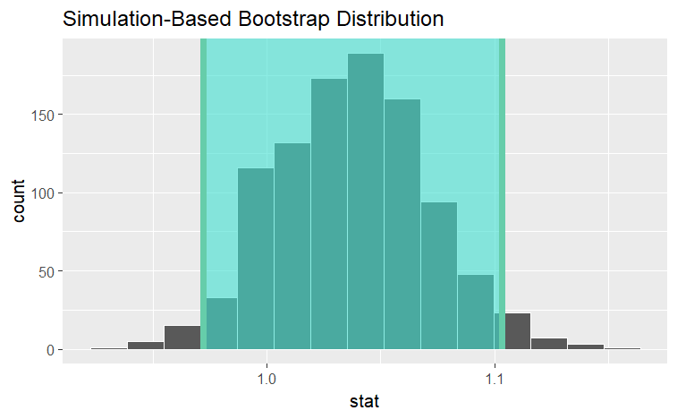

```r
standard_error_ci <- boot_dist |>
  get_ci(type = "se", point_estimate = d_hat)

visualize(boot_dist) +
  shade_confidence_interval(endpoints = standard_error_ci)
```

# One numerical variable, one categorical (2 levels) (t)

Finding the standardized point estimate, Alternatively, using the observe() wrapper to calculate the observed statistic,

```r
t_hat <- gss |>
  specify(hours ~ college) |>
  calculate(stat = "t", order = c("degree", "no degree"))
t_hat <- gss |>
  observe(hours ~ college,
          stat = "t", order = c("degree", "no degree"))
```

Then, generating a bootstrap distribution,

```r
boot_dist <- gss |>
   specify(hours ~ college) |>
   generate(reps = 1000, type = "bootstrap") |>
   calculate(stat = "t", order = c("degree", "no degree"))
```

Use the bootstrap distribution to find a confidence interval, Visualizing the observed statistic alongside the distribution,

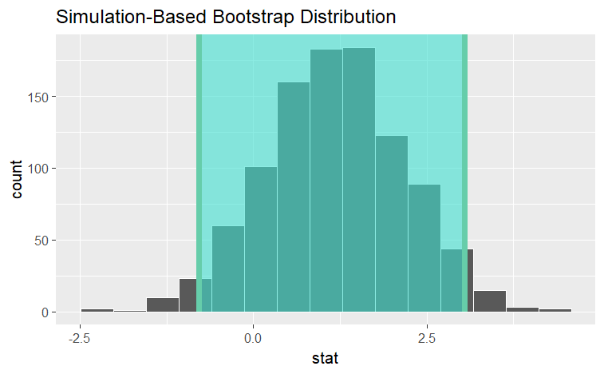

```r
percentile_ci <- get_ci(boot_dist)


visualize(boot_dist) +
  shade_confidence_interval(endpoints = percentile_ci)
```

Alternatively, use the bootstrap distribution to find a confidence interval using the standard error,

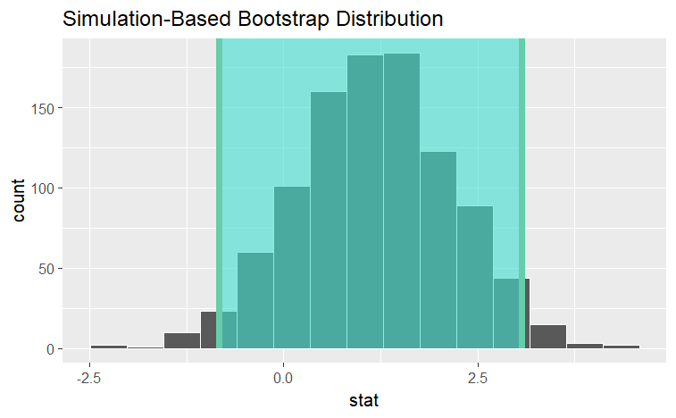

```r
standard_error_ci <- boot_dist |>
  get_ci(type = "se", point_estimate = t_hat)

visualize(boot_dist) +
  shade_confidence_interval(endpoints = standard_error_ci)
```

See the above subsection (diff in means) for a theory-based approach. `infer` does not support confidence intervals on means via the z distribution.

# Two categorical variables (z)

Finding the standardized point estimate, Alternatively, using the observe() wrapper to calculate the observed statistic,

```r
z_hat <- gss |>
  specify(college ~ sex, success = "degree") |>
  calculate(stat = "z", order = c("female", "male"))
z_hat <- gss |>
  observe(college ~ sex, success = "degree",
          stat = "z", order = c("female", "male"))
```

Then, generating a bootstrap distribution,

```r
boot_dist <- gss |>
  specify(college ~ sex, success = "degree") |>
  generate(reps = 1000, type = "bootstrap") |>
  calculate(stat = "z", order = c("female", "male"))
```

Use the bootstrap distribution to find a confidence interval, Visualizing the observed statistic alongside the distribution,

[figure not shown]

```r
percentile_ci <- get_ci(boot_dist)
visualize(boot_dist) +
  shade_confidence_interval(endpoints = percentile_ci)
```

Alternatively, use the bootstrap distribution to find a confidence interval using the standard error,

[figure not shown]

```r
standard_error_ci <- boot_dist |>
  get_ci(type = "se", point_estimate = z_hat)

visualize(boot_dist) +
  shade_confidence_interval(endpoints = standard_error_ci)
```

# Two numerical vars - SLR

Finding the observed statistic, Alternatively, using the observe() wrapper to calculate the observed statistic,

```r
slope_hat <- gss |>
  specify(hours ~ age) |>
  calculate(stat = "slope")

slope_hat <- gss |>
  observe(hours ~ age, stat = "slope")
```

Then, generating a bootstrap distribution,

```r
boot_dist <- gss |>
   specify(hours ~ age) |>
   generate(reps = 1000, type = "bootstrap") |>
   calculate(stat = "slope")
```

Use the bootstrap distribution to find a confidence interval, Visualizing the observed statistic alongside the distribution, Alternatively, use the bootstrap distribution to find a confidence interval using the standard error,

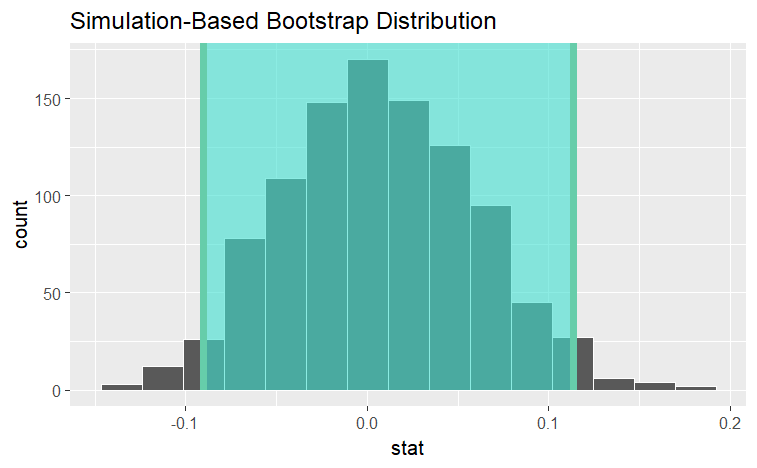

```r
percentile_ci <- get_ci(boot_dist)
visualize(boot_dist) +
  shade_confidence_interval(endpoints = percentile_ci)
```

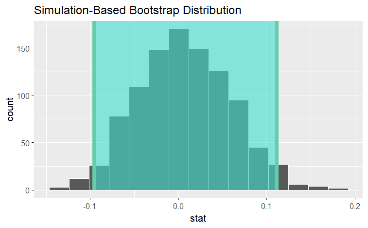

```r
standard_error_ci <- boot_dist |>
  get_ci(type = "se", point_estimate = slope_hat)
visualize(boot_dist) +
  shade_confidence_interval(endpoints = standard_error_ci)
```

# Two numerical vars - correlation

Finding the observed statistic, Alternatively, using the observe() wrapper to calculate the observed statistic,

```r
correlation_hat <- gss |>
  specify(hours ~ age) |>
  calculate(stat = "correlation")
correlation_hat <- gss |>
  observe(hours ~ age, stat = "correlation")
```

Then, generating a bootstrap distribution, Use the bootstrap distribution to find a confidence interval, Visualizing the observed statistic alongside the distribution,

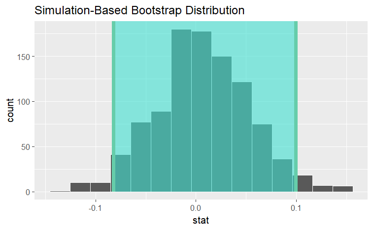

```r
boot_dist <- gss |>
   specify(hours ~ age) |>
   generate(reps = 1000, type = "bootstrap") |>
   calculate(stat = "correlation")
percentile_ci <- get_ci(boot_dist)
visualize(boot_dist) +
  shade_confidence_interval(endpoints = percentile_ci)
```

Alternatively, use the bootstrap distribution to find a confidence interval using the standard error,

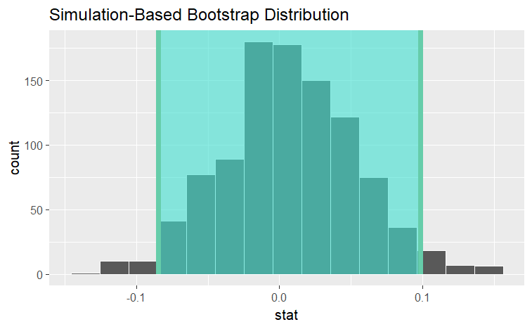

```r
standard_error_ci <- boot_dist |>
  get_ci(type = "se", point_estimate = correlation_hat)

visualize(boot_dist) +
  shade_confidence_interval(endpoints = standard_error_ci)
```

# Two numerical vars - t

Not currently implemented since t could refer to standardized slope or standardized correlation.

# Multiple explanatory variables

Calculating the observed fit,

```r
obs_fit <- gss |>
  specify(hours ~ age + college) |>
  fit()
```

Then, generating a bootstrap distribution, Use the bootstrap distribution to find a confidence interval,

```r
boot_dist <- gss |>
  specify(hours ~ age + college) |>
  generate(reps = 1000, type = "bootstrap") |>
  fit()
conf_ints <-
  get_confidence_interval(
    boot_dist,
    level = .95,
    point_estimate = obs_fit
  )
```

Visualizing the observed statistic alongside the distribution,

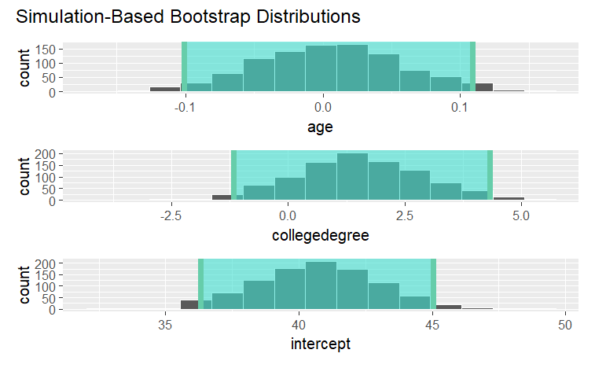

```r
visualize(boot_dist) +
  shade_confidence_interval(endpoints = conf_ints)
```

Note that this fit()-based workflow can be applied to use cases with differing numbers of explanatory variables and explanatory variable types.

# References

The `infer` package. (https://infer.tidymodels.org/)

Full `infer` pipeline examples. (https://infer.tidymodels.org/articles/observed_stat_examples.html)

# Errors

One numerical